# 201800697_김민지 0614

```r
income<-c(160,55,80,60,85,77,100,63,45,50,72,60,150)
insure<-c(20,3.5,3.5,5,10,6.5,3,2.5,1.5,2,2,2.5,15)
ds<-data.frame(income,insure)
head(ds)
```

```
##   income insure
## 1    160   20.0
## 2     55    3.5
## 3     80    3.5
## 4     60    5.0
## 5     85   10.0
## 6     77    6.5
```

# 1번. 산점도 그리고, 표본상관계수 추정 후, 상관관계 존재하는지 검정

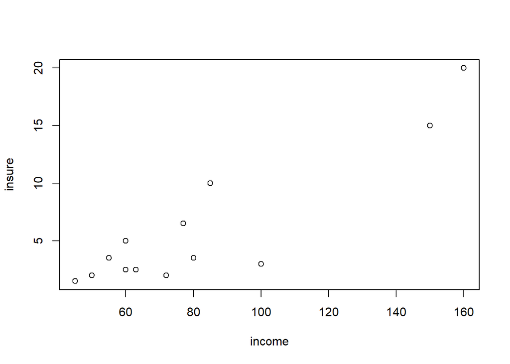

```r
plot(income,insure)
```

```r
cor.test(ds$income,ds$insure,method="pearson")
```

```
##
##  Pearson's product-moment correlation
##
## data:  ds$income and ds$insure
## t = 6.9043, df = 11, p-value = 2.573e-05
## alternative hypothesis: true correlation is not equal to 0
## 95 percent confidence interval:
##  0.6961584 0.9704168
## sample estimates:
##       cor
## 0.9013935
```

- H0 : 월 수입과 보험가입금액 간에는 상관관계가 없다. H1: 상관관계가 있다.
- 통계량 t=6.904(자유도 df=11)
- 유의확률 p=0.00003<0.01 이므로 유의수준 1% 하에서 귀무가설 기각
- 추정된 상관계수 r=0.901
- 따라서, 월 수입과 보험가입금액 간에는 강한 양의 상관관계(0.901)에 있다. 즉, 월 수입이 높은 사람의 보험가입금액이 높은 것으로 나타났다.

# 2번. 분산분석표 작성 후, 회귀직선이 유의한지 검정

```r
mod1=lm(insure~income,data=ds)
summary(mod1)
```

```
##
## Call:
## lm(formula = insure ~ income, data = ds)
##
## Residuals:
##     Min      1Q  Median      3Q     Max
## -5.5942 -0.8070  0.5507  1.3362  3.5493
##
## Coefficients:
##             Estimate Std. Error t value Pr(>|t|)
## (Intercept)  -5.6956     1.8293  -3.114  0.00986 **
## income        0.1429     0.0207   6.904 2.57e-05 ***
## ---
## Signif. codes:  0 '***' 0.001 '**' 0.01 '*' 0.05 '.' 0.1 ' ' 1
##
## Residual standard error: 2.586 on 11 degrees of freedom
## Multiple R-squared:  0.8125, Adjusted R-squared:  0.7955
## F-statistic: 47.67 on 1 and 11 DF,  p-value: 2.573e-05
```

- H0:회귀추정식이 유의하지 않다. H1:회귀추정식이 유의하다.
- 검정통계량 F=47.67 (자유도 df=(1,11))
- 유의확률 p=0.00003로 유의수준 5%하에서 귀무가설 기각된다.
- 따라서, 보험가입금액은 월 수입에 상관없이 차이가 없다고 할 수 없다.

# 3번. 결정계수를 구하고 그 의미 설명

```r
mod2=lm(insure~income,data=ds)
summary(mod2)
```

```
##
## Call:
## lm(formula = insure ~ income, data = ds)
##
## Residuals:
##     Min      1Q  Median      3Q     Max
## -5.5942 -0.8070  0.5507  1.3362  3.5493
##
## Coefficients:
##             Estimate Std. Error t value Pr(>|t|)
## (Intercept)  -5.6956     1.8293  -3.114  0.00986 **
## income        0.1429     0.0207   6.904 2.57e-05 ***
## ---
## Signif. codes:  0 '***' 0.001 '**' 0.01 '*' 0.05 '.' 0.1 ' ' 1
##
## Residual standard error: 2.586 on 11 degrees of freedom
## Multiple R-squared:  0.8125, Adjusted R-squared:  0.7955
## F-statistic: 47.67 on 1 and 11 DF,  p-value: 2.573e-05
```

# 4번. 회귀모형 추정식을 쓰고 그 의미 설명

```r
mod3=lm(insure~income,data=ds)
summary(mod3)
```

```
##
## Call:
## lm(formula = insure ~ income, data = ds)
##
## Residuals:
##     Min      1Q  Median      3Q     Max
## -5.5942 -0.8070  0.5507  1.3362  3.5493
##
## Coefficients:
##             Estimate Std. Error t value Pr(>|t|)
## (Intercept)  -5.6956     1.8293  -3.114  0.00986 **
## income        0.1429     0.0207   6.904 2.57e-05 ***
## ---
## Signif. codes:  0 '***' 0.001 '**' 0.01 '*' 0.05 '.' 0.1 ' ' 1
##
## Residual standard error: 2.586 on 11 degrees of freedom
## Multiple R-squared:  0.8125, Adjusted R-squared:  0.7955
## F-statistic: 47.67 on 1 and 11 DF,  p-value: 2.573e-05
```

```r
#y= -5.697 + 0.143x
```

- 회귀모형 추정식의 의미는 월 수입이 만원씩 높아질 수록 0.14배씩 보험가입금액이 높아진다는 것을 뜻한다.

# 5번. 오차에 대한 가정을 쓰고, 적절한지 설명

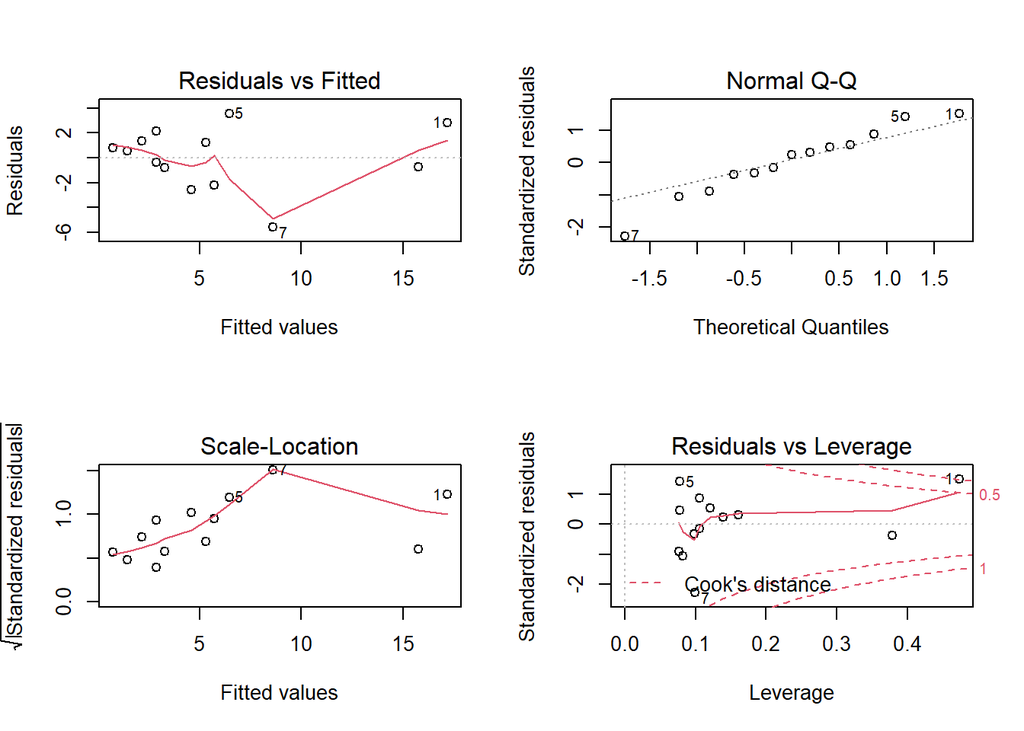

```r
mod4=lm(insure~income,data=ds)
par(mfrow=c(2,2))
plot(mod4)
```

* 정규성 검토 : Q-Q plot을 통해 점들이 점선에 따라 배치되어 있으므로 정규성을 따른다고 할 수 있다. * 등분산성 검토 : Scale-Location을 통해 값이 무작위로 찍히지 않고 왼쪽으로 몰려있으므로 등분산성을 만족하지 않는다고 할 수 있다. * 독립성 검토 : 무작위로 얻은 데이터이기 때문에 독립성을 만족한다.

# 6번. 월 수입이 70만원일때 예상되는 보험가입금액?

```r
y= -5.697 + 0.143*70
y
```

```
## [1] 4.313
```

- 월 수입이 70만원일 때, 예상되는 보험가입금액은 4천3백만원이다.